# Data exploration and clean data

Edward Melendez Mendigure - Eliazar Noa Llascanoa - Yanet Cusi Quispe

05/06/2023

# EXPLORACION Y LIMPIEZA DE DATOS

## 1.1 CONJUNTO DE DATOS

- “BOROUGH”: El código de borough de la propiedad.
- “NEIGHBORHOOD”: El nombre del vecindario de la propiedad.
- “BUILDING CLASS CATEGORY”: La categoría de clase de construcción de la propiedad.
- “TAX CLASS AT PRESENT”: La clase de impuesto actual de la propiedad.
- “BLOCK”: El número de bloque de la propiedad.
- “LOT”: El número de lote de la propiedad.
- “BUILDING CLASS AT PRESENT”: La clase de construcción actual de la propiedad.
- “ADDRESS”: La dirección de la propiedad.
- “ZIP CODE”: El código postal de la propiedad.
- “RESIDENTIAL UNITS”: El número de unidades residenciales en la propiedad.
- “COMMERCIAL UNITS”: El número de unidades comerciales en la propiedad.
- “TOTAL UNITS”: El número total de unidades en la propiedad.
- “LAND SQUARE FEET”: El tamaño del terreno en pies cuadrados.
- “GROSS SQUARE FEET”: El tamaño bruto en pies cuadrados.
- “YEAR BUILT”: El año de construcción de la propiedad.
- “TAX CLASS AT TIME OF SALE”: La clase de impuesto al momento de la venta de la propiedad.
- “BUILDING CLASS AT TIME OF SALE”: La clase de construcción al momento de la venta de la propiedad.
- “SALE PRICE”: El precio de venta de la propiedad.
- “SALE DATE”: La fecha de venta de la propiedad.

### Librerias

```r
library(tidyverse)
library(GGally)
```

### Mostrar data

```r
# EXPLORACION DE DATOS
dataset <- read_csv2("dataset/rollingsales_bronx.csv")
```

```
## ℹ Using "','" as decimal and "'.'" as grouping mark. Use `read_delim()` for more control.
```

```r
#Mostara 3 filas
print(dataset, n = 6, width = Inf)
```

```
## # A tibble: 6,649 × 21
##   BOROUGH NEIGHBORHOOD `BUILDING CLASS CATEGORY` `TAX CLASS AT PRESENT` BLOCK
##     <dbl> <chr>        <chr>                     <chr>                  <dbl>
## 1       2 BATHGATE     01 ONE FAMILY DWELLINGS   1                       2905
## 2       2 BATHGATE     01 ONE FAMILY DWELLINGS   1                       3028
## 3       2 BATHGATE     01 ONE FAMILY DWELLINGS   1                       3030
## 4       2 BATHGATE     01 ONE FAMILY DWELLINGS   1                       3039
## 5       2 BATHGATE     01 ONE FAMILY DWELLINGS   1                       3039
## 6       2 BATHGATE     01 ONE FAMILY DWELLINGS   1                       3046
##     LOT EASEMENT `BUILDING CLASS AT PRESENT` ADDRESS
##   <dbl> <lgl>    <chr>                       <chr>
## 1    26 NA       A9                          1667 WASHINGTON AVENUE
## 2    24 NA       A1                          410 EAST 179TH STREET
## 3    65 NA       A1                          4455 PARK AVENUE
## 4    29 NA       A5                          2327 WASHINGTON AVE
```

[output cut: 35 more lines]

## 1.2 CALIDAD DE DATOS

Visualizemos los datos de forma general

```r
# Resumen de datos
class(dataset)
```

```
## [1] "spec_tbl_df" "tbl_df"      "tbl"         "data.frame"
```

```r
dim(dataset)
```

```
## [1] 6649   21
```

```r
summary(dataset)
```

```
##     BOROUGH  NEIGHBORHOOD       BUILDING CLASS CATEGORY TAX CLASS AT PRESENT
##  Min.   :2   Length:6649        Length:6649             Length:6649
##  1st Qu.:2   Class :character   Class :character        Class :character
##  Median :2   Mode  :character   Mode  :character        Mode  :character
##  Mean   :2
##  3rd Qu.:2
##  Max.   :2
##
##      BLOCK           LOT         EASEMENT       BUILDING CLASS AT PRESENT
##  Min.   :2260   Min.   :   1.0   Mode:logical   Length:6649
##  1st Qu.:3344   1st Qu.:  21.0   NA's:6649      Class :character
##  Median :4266   Median :  48.0                  Mode  :character
##  Mean   :4282   Mean   : 309.2
##  3rd Qu.:5339   3rd Qu.: 122.0
##  Max.   :5955   Max.   :9100.0
##
##    ADDRESS          APARTMENT NUMBER      ZIP CODE     RESIDENTIAL UNITS
##  Length:6649        Length:6649        Min.   :10123   Min.   :  0.000
##  Class :character   Class :character   1st Qu.:10461   1st Qu.:  1.000
##  Mode  :character   Mode  :character   Median :10465   Median :  2.000
##                                        Mean   :10464   Mean   :  3.165
##                                        3rd Qu.:10469   3rd Qu.:  2.000
##                                        Max.   :10475   Max.   :355.000
##                                                        NA's   :1264
##  COMMERCIAL UNITS   TOTAL UNITS      LAND SQUARE FEET  GROSS SQUARE FEET
##  Min.   : 0.0000   Min.   :  0.000   Min.   :  1.005   Min.   :  0.000
##  1st Qu.: 0.0000   1st Qu.:  1.000   1st Qu.:  2.233   1st Qu.:  1.668
##  Median : 0.0000   Median :  2.000   Median :  2.500   Median :  2.248
##  Mean   : 0.1979   Mean   :  3.319   Mean   :  9.426   Mean   : 23.838
##  3rd Qu.: 0.0000   3rd Qu.:  2.000   3rd Qu.:  3.742   3rd Qu.:  3.200
##  Max.   :33.0000   Max.   :355.000   Max.   :992.000   Max.   :998.000
##  NA's   :1783      NA's   :1224      NA's   :1826      NA's   :1826
##    YEAR BUILT   TAX CLASS AT TIME OF SALE BUILDING CLASS AT TIME OF SALE
##  Min.   :1884   Min.   :1.000             Length:6649
##  1st Qu.:1925   1st Qu.:1.000             Class :character
##  Median :1940   Median :1.000             Mode  :character
##  Mean   :1945   Mean   :1.489
##  3rd Qu.:1961   3rd Qu.:2.000
##  Max.   :2022   Max.   :4.000
##  NA's   :628
##   SALE PRICE         SALE DATE
##  Length:6649        Length:6649
##  Class :character   Class :character
##  Mode  :character   Mode  :character
##
##
##
##
```

```r
colnames(dataset)
```

```
##  [1] "BOROUGH"                        "NEIGHBORHOOD"
##  [3] "BUILDING CLASS CATEGORY"        "TAX CLASS AT PRESENT"
##  [5] "BLOCK"                          "LOT"
##  [7] "EASEMENT"                       "BUILDING CLASS AT PRESENT"
##  [9] "ADDRESS"                        "APARTMENT NUMBER"
## [11] "ZIP CODE"                       "RESIDENTIAL UNITS"
## [13] "COMMERCIAL UNITS"               "TOTAL UNITS"
## [15] "LAND SQUARE FEET"               "GROSS SQUARE FEET"
## [17] "YEAR BUILT"                     "TAX CLASS AT TIME OF SALE"
## [19] "BUILDING CLASS AT TIME OF SALE" "SALE PRICE"
## [21] "SALE DATE"
```

### Limpieza de datos

```r
# Remover comas y convertir a numérico el tipo SALE PRICE
sale_price <- dataset$`SALE PRICE`
cleaned_sale_price <- as.numeric(gsub(",", ".", sale_price))
dataset$`SALE PRICE`<- cleaned_sale_price

# Calcular la cantidad de valores NA en cada columna
cantidad_nulos <- colSums(is.na(dataset))


#Algunas columnas tienen casi en su totalidad valores nulos, por lo tanto las eliminamos
columnas_a_eliminar <- c("EASEMENT", "APARTMENT NUMBER","BOROUGH")
dataset <- dataset[, !(names(dataset) %in% columnas_a_eliminar)]

#Verificamos nuestro dataset
cantidad_nulos <- colSums(is.na(dataset))


#Ahora vemos algunas columnas con varios valores NA pero en menos cantidad.
#Para esto vamos a reemplazarlos con el promedio. Antes verifiquemos cual es el
#promedio antes de reemplazar

# Obtener los nombres de las columnas numéricas
columnas_numericas <- names(dataset)[sapply(dataset, is.numeric)]

# Recorrer las columnas numéricas y reemplazar los valores NA por el promedio
for (col in columnas_numericas) {
  promedio <- mean(dataset[[col]], na.rm = TRUE)
  dataset[[col]][is.na(dataset[[col]])] <- promedio
}
cantidad_nulos_despues <- colSums(is.na(dataset))


#Hallar la media y la desviacion estandar
isNumericDataset<-dataset %>% summarize_if(is.numeric, mean)
```

1.2.2 Eliminar datos unicos

```r
# Crear una lista para almacenar los resultados
resultados <- list()

# Recorrer las columnas y calcular los resultados
for (col in names(dataset)) {
  num_filas <- nrow(dataset)  # número total de filas en el dataset
  num_valores_unicos <- length(unique(dataset[[col]]))  # cantidad de valores únicos en la columna

  proporcion_valores_unicos <- num_valores_unicos / num_filas

  if (proporcion_valores_unicos > 0.9) {
    resultado <- "---DATOS UNICOS"
  } else {
    resultado <- "->Datos distintos"
  }

  resultados[[col]] <- resultado
}

# Mostrar el dataframe resultante
resultados
```

```
## $NEIGHBORHOOD
## [1] "->Datos distintos"
##
## $`BUILDING CLASS CATEGORY`
## [1] "->Datos distintos"
##
## $`TAX CLASS AT PRESENT`
## [1] "->Datos distintos"
##
## $BLOCK
## [1] "->Datos distintos"
##
## $LOT
## [1] "->Datos distintos"
##
## $`BUILDING CLASS AT PRESENT`
## [1] "->Datos distintos"
##
## $ADDRESS
## [1] "---DATOS UNICOS"
##
## $`ZIP CODE`
## [1] "->Datos distintos"
##
## $`RESIDENTIAL UNITS`
## [1] "->Datos distintos"
##
## $`COMMERCIAL UNITS`
## [1] "->Datos distintos"
##
## $`TOTAL UNITS`
## [1] "->Datos distintos"
##
## $`LAND SQUARE FEET`
## [1] "->Datos distintos"
##
## $`GROSS SQUARE FEET`
## [1] "->Datos distintos"
##
## $`YEAR BUILT`
## [1] "->Datos distintos"
##
## $`TAX CLASS AT TIME OF SALE`
## [1] "->Datos distintos"
##
## $`BUILDING CLASS AT TIME OF SALE`
## [1] "->Datos distintos"
##
## $`SALE PRICE`
## [1] "->Datos distintos"
##
## $`SALE DATE`
## [1] "->Datos distintos"
```

```r
# ELIMINAR COLUMNA CON DATOS UNICOS
columnas_a_eliminar <- c("ADDRESS")
dataset <- dataset[, !(names(dataset) %in% columnas_a_eliminar)]
dim(dataset)
```

```
## [1] 6649   17
```

1.2.2 Eliminar datos inusuales o absurdos

```r
# Supongamos que tienes una columna llamada 'fecha' en tu conjunto de datos
dataset$`SALE DATE` <- as.Date(dataset$`SALE DATE`)  # Convertir la columna 'fecha' a tipo Date

# Luego, puedes convertir la columna de fecha a tipo numérico
dataset$`SALE DATE` <- as.numeric(dataset$`SALE DATE`)

breaks <- quantile(dataset$`SALE PRICE`, probs = c(0, 0.33, 0.67, 1))
breaks
```

```
##      0%     33%     67%    100%
##   0.000 100.000 491.240 999.999
```

```r
dataset$`SALE PRICE` <- cut(dataset$`SALE PRICE`,
                          breaks = breaks,
                          labels = c(0, 1, 2))

#Actualizar valores numericos
columnas_numericas <- names(dataset)[sapply(dataset, is.numeric)]
columnas_NO_numericas <- names(dataset)[!sapply(dataset, is.numeric)]



dataset
```

```
## # A tibble: 6,649 × 17
##    NEIGHBORHOOD `BUILDING CLASS CATEGORY` `TAX CLASS AT PRESENT` BLOCK   LOT
##    <chr>        <chr>                     <chr>                  <dbl> <dbl>
##  1 BATHGATE     01 ONE FAMILY DWELLINGS   1                       2905    26
##  2 BATHGATE     01 ONE FAMILY DWELLINGS   1                       3028    24
##  3 BATHGATE     01 ONE FAMILY DWELLINGS   1                       3030    65
##  4 BATHGATE     01 ONE FAMILY DWELLINGS   1                       3039    29
##  5 BATHGATE     01 ONE FAMILY DWELLINGS   1                       3039    63
##  6 BATHGATE     01 ONE FAMILY DWELLINGS   1                       3046    38
##  7 BATHGATE     01 ONE FAMILY DWELLINGS   1                       3050    80
##  8 BATHGATE     01 ONE FAMILY DWELLINGS   1                       3050    80
##  9 BATHGATE     01 ONE FAMILY DWELLINGS   1                       3053   102
## 10 BATHGATE     01 ONE FAMILY DWELLINGS   1                       3053   105
## # ℹ 6,639 more rows
## # ℹ 12 more variables: `BUILDING CLASS AT PRESENT` <chr>, `ZIP CODE` <dbl>,
## #   `RESIDENTIAL UNITS` <dbl>, `COMMERCIAL UNITS` <dbl>, `TOTAL UNITS` <dbl>,
## #   `LAND SQUARE FEET` <dbl>, `GROSS SQUARE FEET` <dbl>, `YEAR BUILT` <dbl>,
## #   `TAX CLASS AT TIME OF SALE` <dbl>, `BUILDING CLASS AT TIME OF SALE` <chr>,
## #   `SALE PRICE` <fct>, `SALE DATE` <dbl>
```

## 1.3 AGREGACION

No es necesario hacer la agregacion

## 1.4 MUESTREO - ALEATORIO

```r
take <- sample(seq(nrow(dataset)), size = 100)
muestraDataset<-dataset[take, ]
muestraDataset
```

```
## # A tibble: 100 × 17
##    NEIGHBORHOOD        BUILDING CLASS CATEG…¹ `TAX CLASS AT PRESENT` BLOCK   LOT
##    <chr>               <chr>                  <chr>                  <dbl> <dbl>
##  1 MORRIS PARK/VAN NE… 01 ONE FAMILY DWELLIN… 1                       4201    15
##  2 BAYCHESTER          02 TWO FAMILY DWELLIN… 1                       4978    35
##  3 WOODLAWN            10 COOPS - ELEVATOR A… 2                       3398    44
##  4 SOUNDVIEW           10 COOPS - ELEVATOR A… 2                       3627    20
##  5 BRONXDALE           10 COOPS - ELEVATOR A… 2                       4341     1
##  6 COUNTRY CLUB        04 TAX CLASS 1 CONDOS  1A                      5417  1071
##  7 MOTT HAVEN/PORT MO… 02 TWO FAMILY DWELLIN… 1                       2286   102
##  8 WILLIAMSBRIDGE      31 COMMERCIAL VACANT … 4                       4647    67
##  9 SCHUYLERVILLE/PELH… 02 TWO FAMILY DWELLIN… 1                       5312    96
## 10 BRONXDALE           01 ONE FAMILY DWELLIN… 1                       4587     3
## # ℹ 90 more rows
## # ℹ abbreviated name: ¹`BUILDING CLASS CATEGORY`
## # ℹ 12 more variables: `BUILDING CLASS AT PRESENT` <chr>, `ZIP CODE` <dbl>,
## #   `RESIDENTIAL UNITS` <dbl>, `COMMERCIAL UNITS` <dbl>, `TOTAL UNITS` <dbl>,
## #   `LAND SQUARE FEET` <dbl>, `GROSS SQUARE FEET` <dbl>, `YEAR BUILT` <dbl>,
## #   `TAX CLASS AT TIME OF SALE` <dbl>, `BUILDING CLASS AT TIME OF SALE` <chr>,
## #   `SALE PRICE` <fct>, `SALE DATE` <dbl>
```

## 1.5 ESCALADO MULTIDIMENSIONAL

```r
library(Matrix)
library(arules)
```

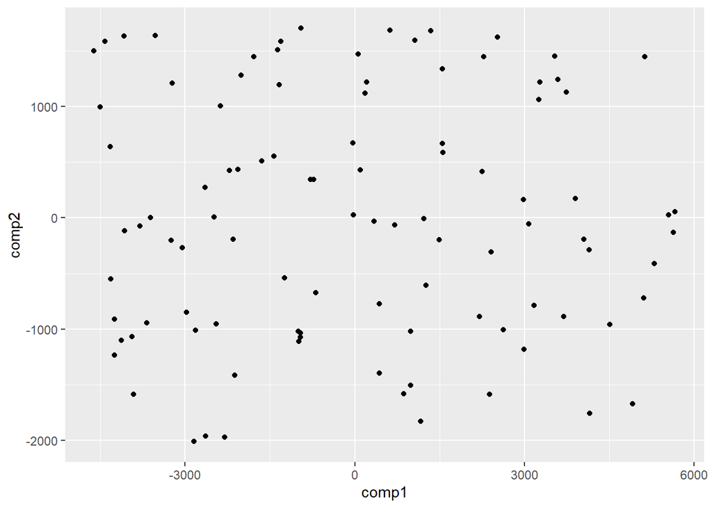

```r
numeric_columns <- sapply(muestraDataset, is.numeric)
selected_columns <- names(muestraDataset)[numeric_columns]
selected_columns <- selected_columns[!selected_columns %in% "SALE PRICE"]
d <- muestraDataset %>% select(all_of(selected_columns)) %>% dist()
fit <- cmdscale(d, k = 2)
colnames(fit) <- c("comp1", "comp2")
fit <- as_tibble(fit) %>% add_column("SALE PRICE" = muestraDataset$"SALE PRICE")
ggplot(fit, aes(x = comp1, y = comp2)) + geom_point()
```

### Discretizacion de caracteristicas

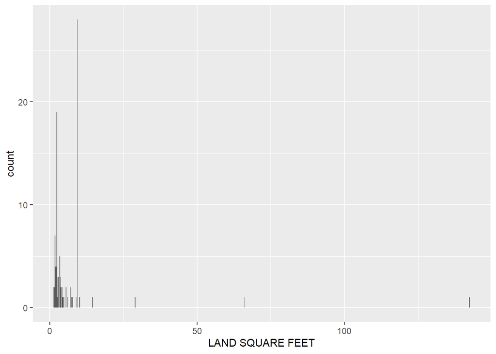

```r
ggplot(muestraDataset, aes(x = `LAND SQUARE FEET` )) + geom_histogram(binwidth = .2)
```

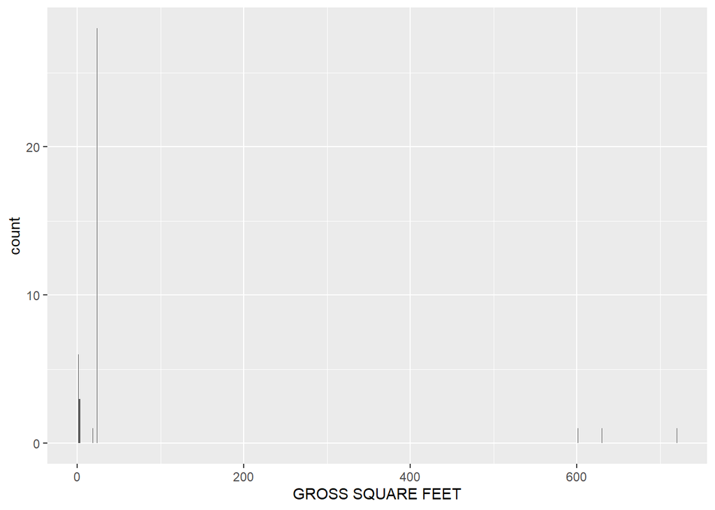

```r
ggplot(muestraDataset, aes(x = `GROSS SQUARE FEET` )) + geom_histogram(binwidth = .2)
```

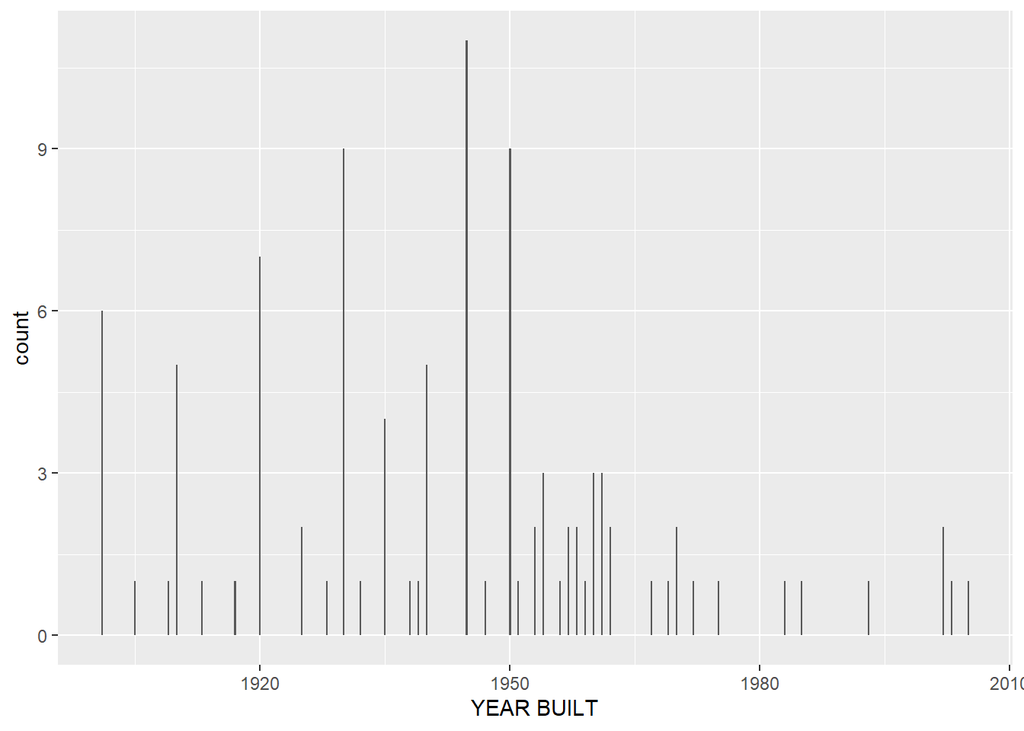

```r
ggplot(muestraDataset, aes(x = `YEAR BUILT` )) + geom_histogram(binwidth = .2)
```

### Estandarizacion de datos

```r
scale_numeric <- function(x) x %>% mutate_if(is.numeric, function(y) as.vector(scale(y)))
muestraDataset <- muestraDataset %>% scale_numeric()
summary(muestraDataset)
```

```
##  NEIGHBORHOOD       BUILDING CLASS CATEGORY TAX CLASS AT PRESENT
##  Length:100         Length:100              Length:100
##  Class :character   Class :character        Class :character
##  Mode  :character   Mode  :character        Mode  :character
##
##
##
##      BLOCK               LOT          BUILDING CLASS AT PRESENT
##  Min.   :-1.85013   Min.   :-0.3794   Length:100
##  1st Qu.:-0.85367   1st Qu.:-0.3428   Class :character
##  Median :-0.04709   Median :-0.2996   Mode  :character
##  Mean   : 0.00000   Mean   : 0.0000
##  3rd Qu.: 1.00680   3rd Qu.:-0.1860
##  Max.   : 1.54660   Max.   : 6.1191
##     ZIP CODE       RESIDENTIAL UNITS  COMMERCIAL UNITS    TOTAL UNITS
##  Min.   :-2.4374   Min.   :-0.99436   Min.   :-0.25341   Min.   :-0.9792
##  1st Qu.:-0.5796   1st Qu.:-0.50324   1st Qu.:-0.25341   1st Qu.:-0.5454
##  Median :-0.1152   Median :-0.01212   Median :-0.25341   Median :-0.1115
##  Mean   : 0.0000   Mean   : 0.00000   Mean   : 0.00000   Mean   : 0.0000
##  3rd Qu.: 0.9066   3rd Qu.: 0.47901   3rd Qu.:-0.05706   3rd Qu.: 0.3570
##  Max.   : 1.6497   Max.   : 8.33697   Max.   : 8.67593   Max.   : 8.1318
##  LAND SQUARE FEET  GROSS SQUARE FEET    YEAR BUILT
##  Min.   :-0.3913   Min.   :-0.25350   Min.   :-1.74623
##  1st Qu.:-0.3153   1st Qu.:-0.23708   1st Qu.:-0.55376
##  Median :-0.2497   Median :-0.22731   Median : 0.08518
##  Mean   : 0.0000   Mean   : 0.00000   Mean   : 0.00000
##  3rd Qu.: 0.1328   3rd Qu.:-0.03833   3rd Qu.: 0.59687
##  Max.   : 8.7305   Max.   : 6.24547   Max.   : 2.60525
##  TAX CLASS AT TIME OF SALE BUILDING CLASS AT TIME OF SALE SALE PRICE
##  Min.   :-0.6051           Length:100                     0   : 3
##  1st Qu.:-0.6051           Class :character               1   :33
##  Median :-0.6051           Mode  :character               2   :37
##  Mean   : 0.0000                                          NA's:27
##  3rd Qu.: 0.5155
##  Max.   : 2.7566
##    SALE DATE
##  Min.   :-1.919797
##  1st Qu.:-0.809187
##  Median :-0.007959
##  Mean   : 0.000000
##  3rd Qu.: 0.834249
##  Max.   : 1.563846
```

### Proximidades y distancias

```r
people <- muestraDataset %>% mutate_if(is.character, factor)
people
```

```
## # A tibble: 100 × 17
##    NEIGHBORHOOD     BUILDING CLASS CATEG…¹ `TAX CLASS AT PRESENT`   BLOCK    LOT
##    <fct>            <fct>                  <fct>                    <dbl>  <dbl>
##  1 MORRIS PARK/VAN… 01 ONE FAMILY DWELLIN… 1                      -0.0763 -0.357
##  2 BAYCHESTER       02 TWO FAMILY DWELLIN… 1                       0.643  -0.324
##  3 WOODLAWN         10 COOPS - ELEVATOR A… 2                      -0.820  -0.309
##  4 SOUNDVIEW        10 COOPS - ELEVATOR A… 2                      -0.608  -0.348
##  5 BRONXDALE        10 COOPS - ELEVATOR A… 2                       0.0534 -0.379
##  6 COUNTRY CLUB     04 TAX CLASS 1 CONDOS  1A                      1.05    1.36
##  7 MOTT HAVEN/PORT… 02 TWO FAMILY DWELLIN… 1                      -1.85   -0.215
##  8 WILLIAMSBRIDGE   31 COMMERCIAL VACANT … 4                       0.337  -0.272
##  9 SCHUYLERVILLE/P… 02 TWO FAMILY DWELLIN… 1                       0.953  -0.225
## 10 BRONXDALE        01 ONE FAMILY DWELLIN… 1                       0.281  -0.376
## # ℹ 90 more rows
## # ℹ abbreviated name: ¹`BUILDING CLASS CATEGORY`
## # ℹ 12 more variables: `BUILDING CLASS AT PRESENT` <fct>, `ZIP CODE` <dbl>,
## #   `RESIDENTIAL UNITS` <dbl>, `COMMERCIAL UNITS` <dbl>, `TOTAL UNITS` <dbl>,
## #   `LAND SQUARE FEET` <dbl>, `GROSS SQUARE FEET` <dbl>, `YEAR BUILT` <dbl>,
## #   `TAX CLASS AT TIME OF SALE` <dbl>, `BUILDING CLASS AT TIME OF SALE` <fct>,
## #   `SALE PRICE` <fct>, `SALE DATE` <dbl>
```

### Ver matriz de correlacion

```r
cc <- muestraDataset %>% select(-columnas_NO_numericas) %>% cor()
cc
```

```
##                                  BLOCK         LOT    ZIP CODE
## BLOCK                      1.000000000  0.11327940  0.36941313
## LOT                        0.113279398  1.00000000  0.02491418
## ZIP CODE                   0.369413132  0.02491418  1.00000000
## RESIDENTIAL UNITS         -0.018457883 -0.10577531  0.08340544
## COMMERCIAL UNITS          -0.059319738 -0.03391932 -0.09480057
## TOTAL UNITS               -0.045395701 -0.12455795  0.03114788
## LAND SQUARE FEET           0.006821972  0.01377761 -0.06633911
## GROSS SQUARE FEET          0.039190469 -0.01067428  0.07983835
## YEAR BUILT                 0.244922910  0.12531587 -0.02501523
## TAX CLASS AT TIME OF SALE -0.186968270  0.02245703 -0.28698800
## SALE DATE                  0.011580952 -0.07419396 -0.02650106
##                           RESIDENTIAL UNITS COMMERCIAL UNITS TOTAL UNITS
## BLOCK                           -0.01845788      -0.05931974 -0.04539570
## LOT                             -0.10577531      -0.03391932 -0.12455795
## ZIP CODE                         0.08340544      -0.09480057  0.03114788
## RESIDENTIAL UNITS                1.00000000       0.03360014  0.89889664
## COMMERCIAL UNITS                 0.03360014       1.00000000  0.46755059
## TOTAL UNITS                      0.89889664       0.46755059  1.00000000
## LAND SQUARE FEET                -0.13146590       0.11487277 -0.06724475
## GROSS SQUARE FEET               -0.08753754       0.02001418 -0.06819189
## YEAR BUILT                      -0.11190237      -0.08910357 -0.14607532
## TAX CLASS AT TIME OF SALE       -0.08819498       0.47341055  0.12681876
## SALE DATE                       -0.06963518      -0.12853873 -0.11555882
##                           LAND SQUARE FEET GROSS SQUARE FEET   YEAR BUILT
## BLOCK                          0.006821972       0.039190469  0.244922910
## LOT                            0.013777615      -0.010674284  0.125315874
## ZIP CODE                      -0.066339111       0.079838348 -0.025015232
## RESIDENTIAL UNITS             -0.131465903      -0.087537537 -0.111902368
## COMMERCIAL UNITS               0.114872775       0.020014181 -0.089103573
## TOTAL UNITS                   -0.067244749      -0.068191891 -0.146075323
## LAND SQUARE FEET               1.000000000       0.445808886  0.126094713
## GROSS SQUARE FEET              0.445808886       1.000000000  0.006714145
## YEAR BUILT                     0.126094713       0.006714145  1.000000000
## TAX CLASS AT TIME OF SALE      0.528754672       0.105421974  0.122932135
## SALE DATE                      0.062419347       0.010223831 -0.005823633
##                           TAX CLASS AT TIME OF SALE    SALE DATE
## BLOCK                                   -0.18696827  0.011580952
## LOT                                      0.02245703 -0.074193962
## ZIP CODE                                -0.28698800 -0.026501056
## RESIDENTIAL UNITS                       -0.08819498 -0.069635184
## COMMERCIAL UNITS                         0.47341055 -0.128538730
## TOTAL UNITS                              0.12681876 -0.115558817
## LAND SQUARE FEET                         0.52875467  0.062419347
## GROSS SQUARE FEET                        0.10542197  0.010223831
## YEAR BUILT                               0.12293214 -0.005823633
## TAX CLASS AT TIME OF SALE                1.00000000  0.064433577
## SALE DATE                                0.06443358  1.000000000
```

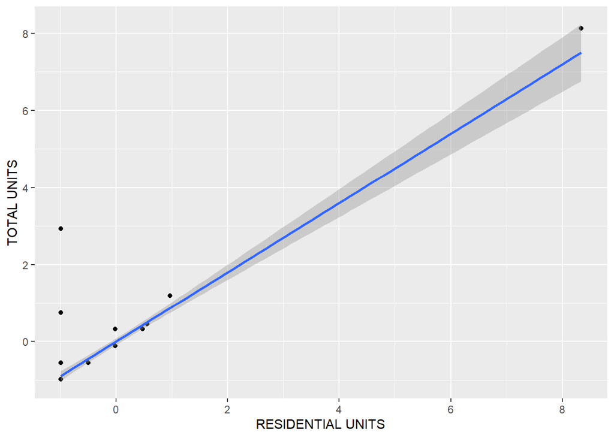

```r
ggplot(muestraDataset, aes(`RESIDENTIAL UNITS`, `TOTAL UNITS`)) +
  geom_point() +
  geom_smooth(method = "lm")
```

### ESTIMACION DE DENSIDAD

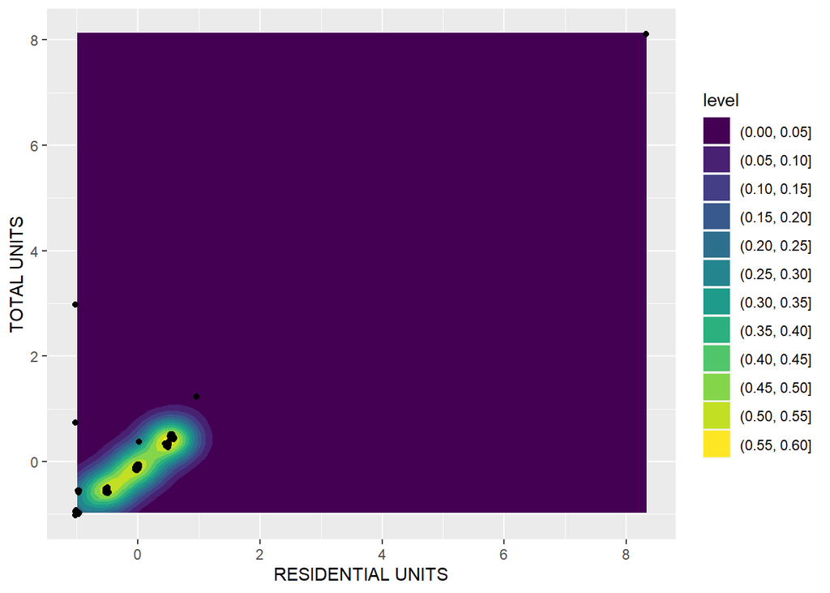

```r
library(tidyverse)

#Dos dimensiones
ggplot(muestraDataset, aes(`RESIDENTIAL UNITS`, `TOTAL UNITS`)) +
  geom_density_2d_filled() +
  geom_jitter()
```

### Matriz de correlacion img

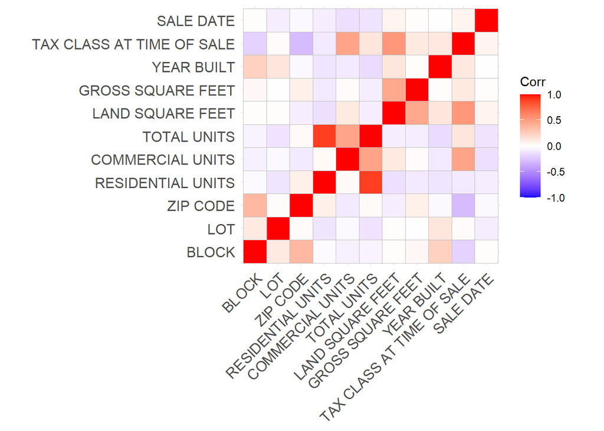

```r
library(ggcorrplot)
library(seriation)
library(corrplot)
cm1 <- muestraDataset %>% select(-columnas_NO_numericas,-`SALE PRICE`) %>% as.matrix %>% cor()
ggcorrplot(cm1)
```

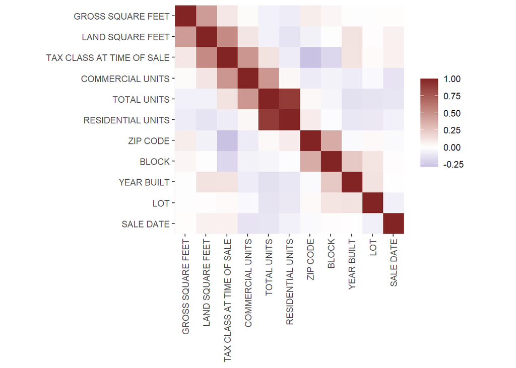

```r
#Vemos otro
gghmap(cm1, prop = TRUE)
```

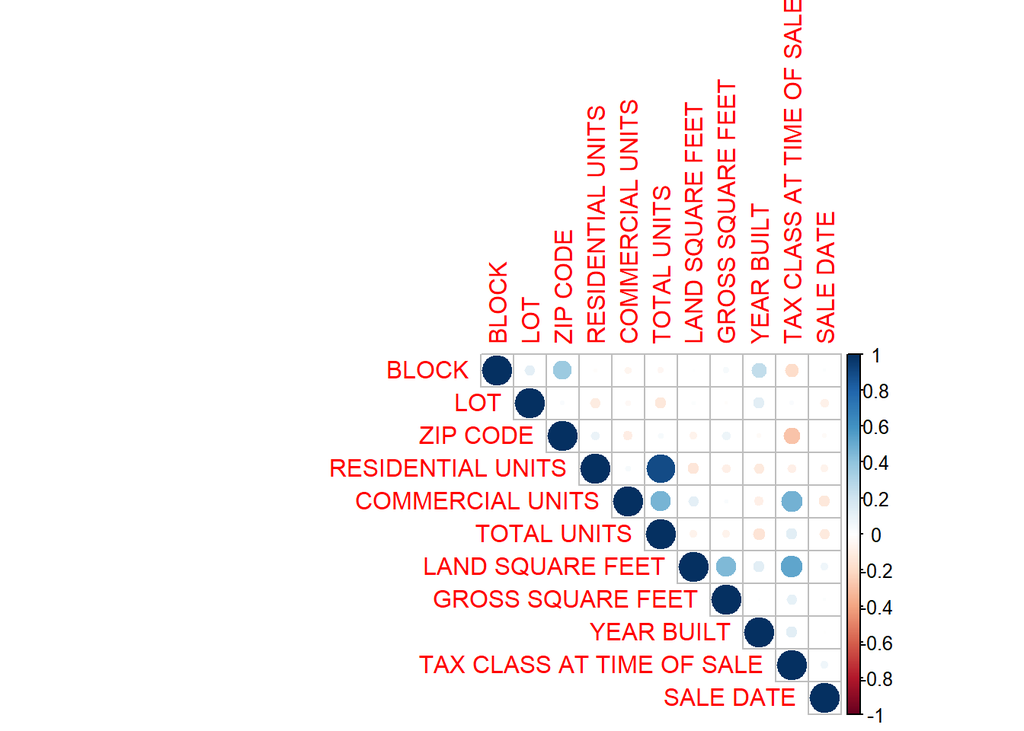

```r
# Visualiza la matriz de correlación
corrplot(cm1, type = "upper", method = "circle")
```

### CONVERSION DE DATOS CATEGORICOS A NUMERICOS CON FACTORES

```r
# Seleccionar las columnas categóricas que se convertirán en factores
muestraDataset[columnas_NO_numericas] <- lapply(muestraDataset[columnas_NO_numericas], factor)

# Convertir los factores a variables numericas
muestraDataset[columnas_NO_numericas] <- lapply(muestraDataset[columnas_NO_numericas], as.numeric)

# Imprimir el resultado
muestraDataset
```

```
## # A tibble: 100 × 17
##    NEIGHBORHOOD `BUILDING CLASS CATEGORY` `TAX CLASS AT PRESENT`   BLOCK    LOT
##           <dbl>                     <dbl>                  <dbl>   <dbl>  <dbl>
##  1           15                         1                      1 -0.0763 -0.357
##  2            2                         2                      1  0.643  -0.324
##  3           28                         8                      4 -0.820  -0.309
##  4           24                         8                      4 -0.608  -0.348
##  5            5                         8                      4  0.0534 -0.379
##  6            8                         4                      2  1.05    1.36
##  7           17                         2                      1 -1.85   -0.215
##  8           27                        13                      6  0.337  -0.272
##  9           23                         2                      1  0.953  -0.225
## 10            5                         1                      1  0.281  -0.376
## # ℹ 90 more rows
## # ℹ 12 more variables: `BUILDING CLASS AT PRESENT` <dbl>, `ZIP CODE` <dbl>,
## #   `RESIDENTIAL UNITS` <dbl>, `COMMERCIAL UNITS` <dbl>, `TOTAL UNITS` <dbl>,
## #   `LAND SQUARE FEET` <dbl>, `GROSS SQUARE FEET` <dbl>, `YEAR BUILT` <dbl>,
## #   `TAX CLASS AT TIME OF SALE` <dbl>, `BUILDING CLASS AT TIME OF SALE` <dbl>,
## #   `SALE PRICE` <dbl>, `SALE DATE` <dbl>
```

### VISUALIZAR DATOS ATIPICOS DE COLUMNAS NUMERICAS

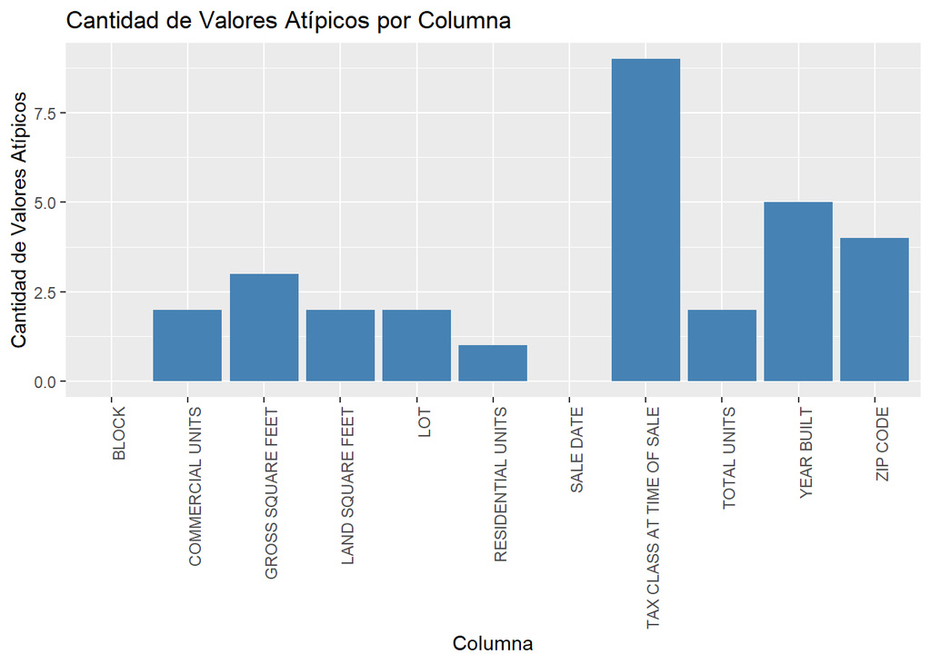

```r
library(ggplot2)
# Calcular la cantidad de valores atípicos en cada columna numérica
valores_atipicos <- sapply(muestraDataset[, columnas_numericas], function(x) {
  limite_superior <- mean(x) + 2 * sd(x)
  limite_inferior <- mean(x) - 2 * sd(x)
  sum(x < limite_inferior | x > limite_superior)
})

# Crear un dataframe con los nombres de las columnas y la cantidad de valores atípicos
datos_atipicos <- data.frame(Columna = names(valores_atipicos),
                             Valores_Atípicos = valores_atipicos)

# Crear el gráfico de barras
grafico <- ggplot(datos_atipicos, aes(x = Columna, y = Valores_Atípicos)) +
  geom_bar(stat = "identity", fill = "steelblue") +
  labs(title = "Cantidad de Valores Atípicos por Columna",
       x = "Columna", y = "Cantidad de Valores Atípicos") +
  theme(axis.text.x = element_text(angle = 90, hjust = 1))

# Mostrar el gráfico
print(grafico)
```

### Eiminar datos atipicos de las columnas numericas

```r
#---------------------------------------------------------------------
# Calcular los límites para identificar los valores atípicos en cada columna numérica
limites <- sapply(muestraDataset[, columnas_numericas], function(x) {
  limite_superior <- mean(x) + 2 * sd(x)
  limite_inferior <- mean(x) - 2 * sd(x)
  list(limite_inferior = limite_inferior, limite_superior = limite_superior)
})

# Eliminar los valores atípicos en cada columna numérica
datos_sin_atipicos <- muestraDataset
for (i in 1:length(columnas_numericas)) {
  columna <- names(columnas_numericas)[i]
  limite_inf <- limites$limite_inferior[i]
  limite_sup <- limites$limite_superior[i]
  datos_sin_atipicos[, columna] <- ifelse(muestraDataset[, columna] >= limite_inf & muestraDataset[, columna] <= limite_sup,
                                          muestraDataset[, columna], NA)
}

# Eliminar filas que contienen valores atípicos en al menos una columna numérica
datos_sin_atipicos <- datos_sin_atipicos[complete.cases(datos_sin_atipicos), ]

#VISUALIZAR NUESTRA RELACION DE COLUMNAS
cm1 <- datos_sin_atipicos %>% select(-columnas_NO_numericas,-`SALE PRICE`) %>% as.matrix %>% cor()
cm1
```

```
##                                 BLOCK         LOT    ZIP CODE RESIDENTIAL UNITS
## BLOCK                      1.00000000  0.20891889  0.42064507       -0.02733360
## LOT                        0.20891889  1.00000000  0.08832917       -0.10314634
## ZIP CODE                   0.42064507  0.08832917  1.00000000        0.08347311
## RESIDENTIAL UNITS         -0.02733360 -0.10314634  0.08347311        1.00000000
## COMMERCIAL UNITS          -0.05860160 -0.05609907 -0.10214442        0.03041390
## TOTAL UNITS               -0.05432595 -0.12921838  0.02614921        0.89511625
## LAND SQUARE FEET           0.04010487  0.05679262 -0.03305203       -0.10985455
## GROSS SQUARE FEET          0.22753604  0.28498798  0.10333693        0.32769458
## YEAR BUILT                 0.29402858  0.17502736  0.08849166       -0.14042829
## TAX CLASS AT TIME OF SALE -0.21484921 -0.05910561 -0.32617622       -0.09600558
## SALE DATE                 -0.02476001 -0.21219342 -0.05840875       -0.02745007
##                           COMMERCIAL UNITS TOTAL UNITS LAND SQUARE FEET
## BLOCK                          -0.05860160 -0.05432595       0.04010487
## LOT                            -0.05609907 -0.12921838       0.05679262
## ZIP CODE                       -0.10214442  0.02614921      -0.03305203
## RESIDENTIAL UNITS               0.03041390  0.89511625      -0.10985455
## COMMERCIAL UNITS                1.00000000  0.47243107       0.08035428
## TOTAL UNITS                     0.47243107  1.00000000      -0.06424583
## LAND SQUARE FEET                0.08035428 -0.06424583       1.00000000
## GROSS SQUARE FEET               0.09197587  0.31663788       0.24384940
## YEAR BUILT                     -0.11049333 -0.18239858       0.20685299
## TAX CLASS AT TIME OF SALE       0.46037563  0.11982303       0.60340349
## SALE DATE                      -0.13127134 -0.07880257       0.03147166
##                           GROSS SQUARE FEET  YEAR BUILT
## BLOCK                            0.22753604  0.29402858
## LOT                              0.28498798  0.17502736
## ZIP CODE                         0.10333693  0.08849166
## RESIDENTIAL UNITS                0.32769458 -0.14042829
## COMMERCIAL UNITS                 0.09197587 -0.11049333
## TOTAL UNITS                      0.31663788 -0.18239858
## LAND SQUARE FEET                 0.24384940  0.20685299
## GROSS SQUARE FEET                1.00000000  0.44045916
## YEAR BUILT                       0.44045916  1.00000000
## TAX CLASS AT TIME OF SALE        0.26318009  0.12638712
## SALE DATE                       -0.07101502  0.06504819
##                           TAX CLASS AT TIME OF SALE   SALE DATE
## BLOCK                                   -0.21484921 -0.02476001
## LOT                                     -0.05910561 -0.21219342
## ZIP CODE                                -0.32617622 -0.05840875
## RESIDENTIAL UNITS                       -0.09600558 -0.02745007
## COMMERCIAL UNITS                         0.46037563 -0.13127134
## TOTAL UNITS                              0.11982303 -0.07880257
## LAND SQUARE FEET                         0.60340349  0.03147166
## GROSS SQUARE FEET                        0.26318009 -0.07101502
## YEAR BUILT                               0.12638712  0.06504819
## TAX CLASS AT TIME OF SALE                1.00000000  0.10296055
## SALE DATE                                0.10296055  1.00000000
```

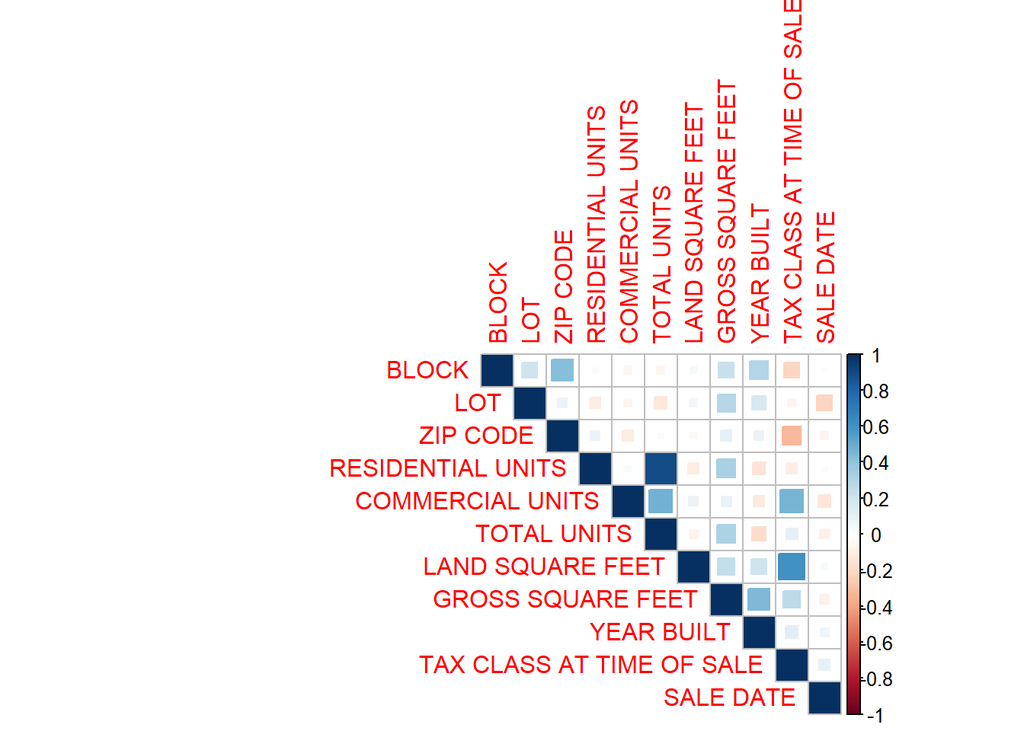

```r
# Visualiza la matriz de correlación
corrplot(cm1, type = "upper", method = "square")
```

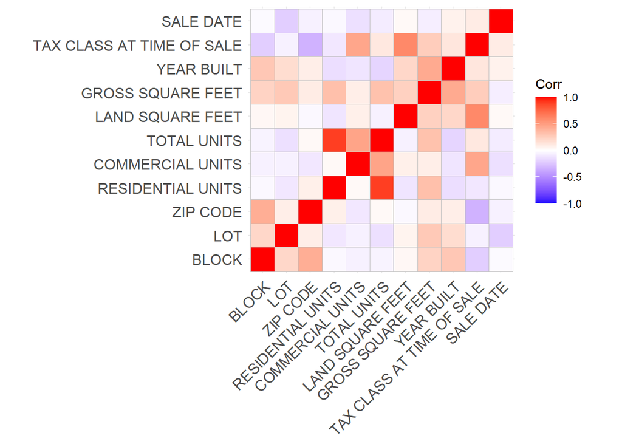

```r
ggcorrplot(cm1)
```

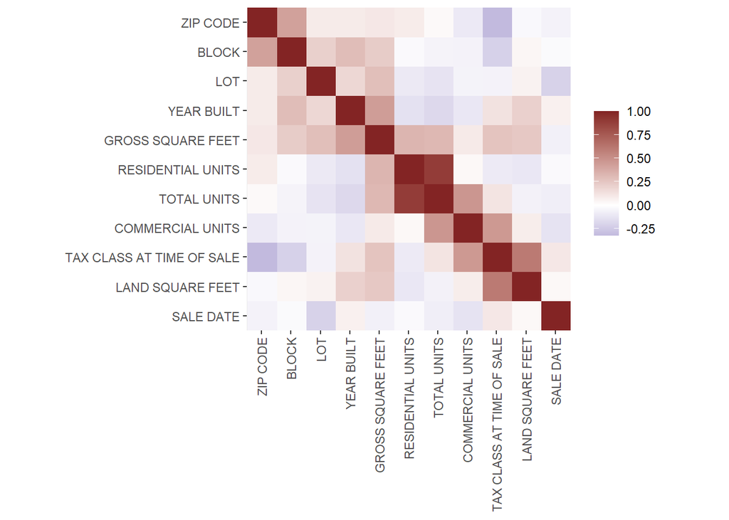

```r
gghmap(cm1, prop = TRUE)
```

DE LAS VARIABLES VISTAS LAS COLUMNAS QUE TIENEN MAYOR CORRELACION SON: `LAND SQUARE FEET` `TAX CLASS AT TIME OF SALE` `COMMERCIAL UNIT` `BLOCK` `ZIP CODE` `RESIDENTIAL UNITS` `TOTAL UNITS`